# Week 2: Data Pre-Processing and Exploration

## Deal with Data Outliers and Noises (2)

After removing outliers

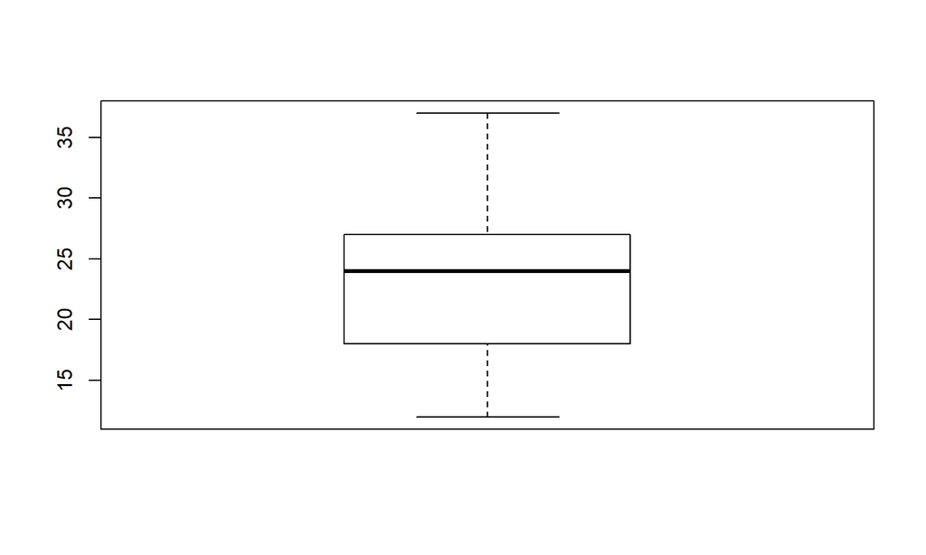

```r
mpg$hwy[mpg$hwy %in% boxplot.stats(mpg$hwy)$out] <- median(mpg$hwy, na.rm = T)
boxplot(mpg$hwy)
```

## Remove Duplicate Data Record

```r
nrow(mpg)
```

```
## [1] 234
```

```r
nrow(mpg[!duplicated(mpg), ])
```

```
## [1] 225
```

```r
mpg %>%
  distinct(.keep_all = T) %>%
  nrow()
```

```
## [1] 225
```

## Output those Duplicated Records

```r
mpg[duplicated(mpg)|duplicated(mpg, fromLast = T), ]
```

```
## # A tibble: 18 x 12
##    manufacturer model displ  year   cyl trans drv     cty   hwy fl    class
##    <fct>        <fct> <dbl> <int> <int> <fct> <fct> <int> <dbl> <fct> <fct>
##  1 chevrolet    c150~   5.3  2008     8 auto~ r        14    20 r     suv
##  2 chevrolet    c150~   5.3  2008     8 auto~ r        14    20 r     suv
##  3 dodge        cara~   3.3  1999     6 auto~ f        16    22 r     mini~
##  4 dodge        cara~   3.3  1999     6 auto~ f        16    22 r     mini~
##  5 dodge        cara~   3.3  2008     6 auto~ f        17    24 r     mini~
##  6 dodge        cara~   3.3  2008     6 auto~ f        17    24 r     mini~
##  7 dodge        dako~   4.7  2008     8 auto~ 4        14    19 r     pick~
##  8 dodge        dako~   4.7  2008     8 auto~ 4        14    19 r     pick~
##  9 dodge        dura~   4.7  2008     8 auto~ 4        13    17 r     suv
## 10 dodge        dura~   4.7  2008     8 auto~ 4        13    17 r     suv
## 11 dodge        ram ~   4.7  2008     8 manu~ 4        12    16 r     pick~
## 12 dodge        ram ~   4.7  2008     8 auto~ 4        13    17 r     pick~
## 13 dodge        ram ~   4.7  2008     8 auto~ 4        13    17 r     pick~
## 14 dodge        ram ~   4.7  2008     8 manu~ 4        12    16 r     pick~
## 15 ford         expl~   4    1999     6 auto~ 4        14    17 r     suv
## 16 ford         expl~   4    1999     6 auto~ 4        14    17 r     suv
## 17 honda        civic   1.6  1999     4 auto~ f        24    32 r     subc~
## 18 honda        civic   1.6  1999     4 auto~ f        24    32 r     subc~
## # ... with 1 more variable: displ_grp <fct>
```

## Aggregation

```r
mpg %>%
  group_by(manufacturer) %>%
  summarise(avg_cty = mean(cty)) %>%
  arrange(desc(avg_cty)) %>%
  head(5)
```

```
## # A tibble: 5 x 2
##   manufacturer avg_cty
##   <fct>          <dbl>
## 1 honda           24.4
## 2 volkswagen      20.9
## 3 subaru          19.3
## 4 hyundai         18.6
## 5 toyota          18.5
```

## Random Data Sampling without Replacement

```r
mpg_sample_index <- sample(1:nrow(mpg),
                           size = nrow(mpg) * 0.3,
                           replace = F)
prop.table(table(mpg[mpg_sample_index, "drv"]))
```

```
##
##         4         f         r
## 0.4285714 0.4571429 0.1142857
```

```r
mpg[mpg_sample_index, ]
```

```
## # A tibble: 70 x 12
##    manufacturer model displ  year   cyl trans drv     cty   hwy fl    class
##    <fct>        <fct> <dbl> <int> <int> <fct> <fct> <int> <dbl> <fct> <fct>
##  1 dodge        dako~   4.7  2008     8 auto~ 4        14    19 r     pick~
##  2 nissan       maxi~   3    1999     6 auto~ f        18    26 r     mids~
##  3 volkswagen   gti     2    1999     4 auto~ f        19    26 r     comp~
##  4 volkswagen   pass~   2    2008     4 manu~ f        21    29 p     mids~
##  5 chevrolet    corv~   7    2008     8 manu~ r        15    24 p     2sea~
##  6 chevrolet    corv~   6.2  2008     8 manu~ r        16    26 p     2sea~
##  7 toyota       camry   2.2  1999     4 manu~ f        21    29 r     mids~
##  8 audi         a4 q~   3.1  2008     6 manu~ 4        15    25 p     comp~
##  9 dodge        dako~   5.2  1999     8 auto~ 4        11    15 r     pick~
## 10 dodge        cara~   2.4  1999     4 auto~ f        18    24 r     mini~
## # ... with 60 more rows, and 1 more variable: displ_grp <fct>
```

## Stratified Data Sampling

```r
prop.table(table(mpg$drv))
```

```
##
##         4         f         r
## 0.4401709 0.4529915 0.1068376
```

```r
sample_index <- caret::createDataPartition(mpg$drv, p = 0.3,
                                    list = F)
prop.table(table(mpg[sample_index, "drv"]))
```

```
##
##         4         f         r
## 0.4366197 0.4507042 0.1126761
```

## Missing Value Manipulations (1)

Check if missing values exist in the dataset. If not, then randomly assign some missing values and check how many missing values exist for which variables.

```r
sum(!complete.cases(mpg))
```

```
## [1] 0
```

```r
mpg$hwy[sample(1:length(mpg$hwy), size = 5, replace = F)] <- NA
sum(!complete.cases(mpg))
```

```
## [1] 5
```

```r
sapply(mpg, function(x) sum(is.na(x)))
```

```
## manufacturer        model        displ         year          cyl
##            0            0            0            0            0
##        trans          drv          cty          hwy           fl
##            0            0            0            5            0
##        class    displ_grp
##            0            0
```

## Missing Value Manipulations (2)

Check number of missing values, records with missing values, and attributes with missing values

```r
sum(is.na(mpg))
```

```
## [1] 5
```

```r
which(apply(mpg, 1, function(x) sum(is.na(x))) > 0)
```

```
## [1]  37 116 135 150 155
```

```r
which(apply(mpg, 2, function(x) sum(is.na(x))) > 0)
```

```
## hwy
##   9
```

```r
sum(!complete.cases(mpg))
```

```
## [1] 5
```

## Missing Value Manipulations (3)

Simple imputation method for missing value: replace with mean of the attribute

```r
mpg2 <- mpg
mpg2$hwy[is.na(mpg2$hwy)] <- mean(mpg2$hwy, na.rm = T)
sum(!complete.cases(mpg2))
```

```
## [1] 0
```

More advanced missing value imputation algorithms: kNN imputation

```r
preprocess <- caret::preProcess(mpg, method = c("knnImpute", "center", "scale"))
mpg3 <- predict(preprocess, mpg)
sum(!complete.cases(mpg3))
```

```
## [1] 0
```

## Examine the Missing Value Imputation Values

```r
row <- which(apply(mpg, MARGIN = 1, function(x) sum(is.na(x)) > 0))
col <- which(apply(mpg, MARGIN = 2, function(x) sum(is.na(x)) > 0))
print(as.data.frame(unique(mpg2[row, col])))
```

```
##        hwy
## 1 23.17904
```

```r
mpg3[row, c("manufacturer", "model", "class", "displ", "displ_grp", "cyl", "cty", "hwy")]
```

```
## # A tibble: 5 x 8
##   manufacturer model      class      displ displ_grp     cyl     cty    hwy
##   <fct>        <fct>      <fct>      <dbl> <fct>       <dbl>   <dbl>  <dbl>
## 1 chevrolet    malibu     midsize   0.0992 medium     0.0689  0.0331  0.364
## 2 hyundai      tiburon    subcomp~ -1.14   low       -1.17    0.503   0.616
## 3 lincoln      navigator~ suv       1.49   high       1.31   -1.38   -1.26
## 4 nissan       maxima     midsize   0.0218 medium     0.0689  0.503   0.796
## 5 pontiac      grand prix midsize  -0.288  medium     0.0689  0.268   0.508
```

## Detect Attributes’ Correlation: Correlogram

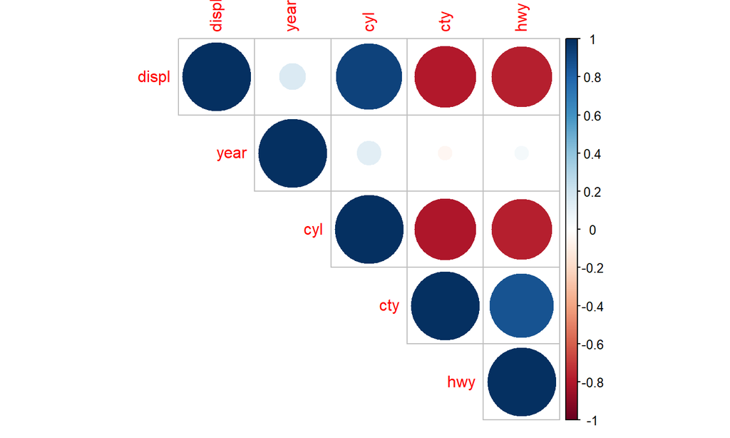

```r
library(corrplot)
cor_matrix <- cor(mpg[complete.cases(mpg), sapply(mpg, is.numeric)], method = "pearson")
corrplot(cor_matrix, type = "upper")
```

## Visualization: Box Plot

Apply to two attributes: one categorical and one numeric attribute.

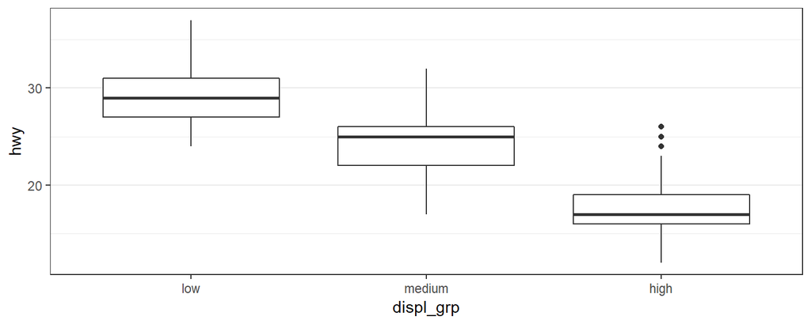

```r
theme_set(theme_bw())

ggplot(mpg, aes(x = displ_grp, y = hwy)) +
  geom_boxplot() +
  theme(panel.grid.major.x = element_blank())
```

## Visualization: Scatter Plot (and its Variants)

Apply to two numeric attributes.

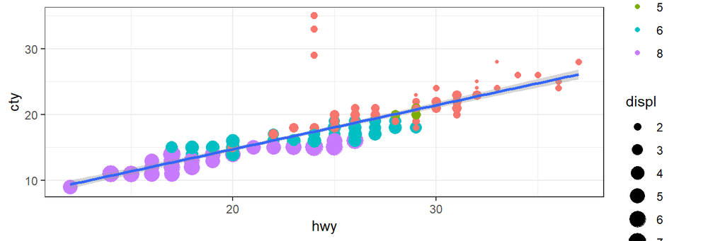

```r
ggplot(mpg, aes(x = hwy, y = cty)) +
  geom_point(aes(color = as.factor(cyl), size = displ)) +
  geom_smooth(method = "lm")
```

## Visualization: Pie Chart

Apply to one categorical attribute (optional: numeric count).

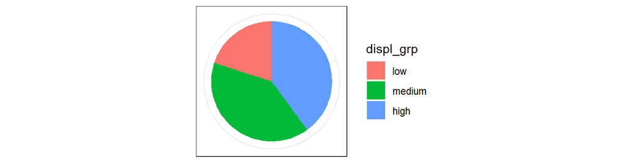

```r
library(scales)
mpg %>%  group_by(displ_grp) %>%
  summarise(pct = percent(n()/nrow(mpg))) %>%
  ggplot(aes(x = factor(1), y = pct, fill = displ_grp)) +
  geom_bar(stat = "identity") +
  coord_polar(theta = "y") +
  theme(axis.ticks = element_blank(),
        axis.text = element_blank(),
        axis.title = element_blank())
```

## Visualization: Ordered Bar Plot

Apply to two attributes: one categorical and one numeric attribute.

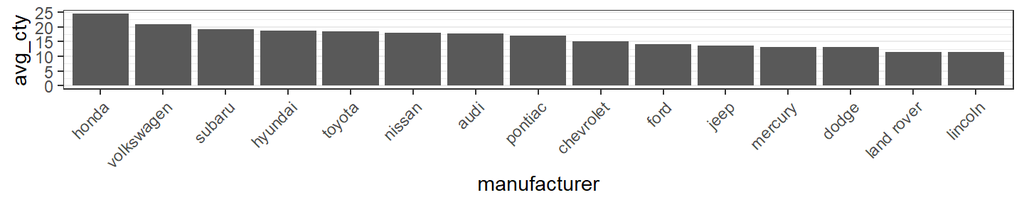

```r
mpg_by_maker <- mpg %>%
  group_by(manufacturer) %>%
  summarise(avg_cty = mean(cty, na.rm = T)) %>%
  arrange(desc(avg_cty))

mpg_by_maker$manufacturer <- factor(mpg_by_maker$manufacturer,
                                    levels = mpg_by_maker$manufacturer)

ggplot(mpg_by_maker, aes(x = manufacturer, y = avg_cty)) +
  geom_bar(stat = "identity") +
  theme(axis.text.x = element_text(angle = 45, hjust = 1),
        panel.grid.major.x = element_blank())
```

## Visualization: Density Plot

Apply to two attributes: one categorical and one numeric attribute.

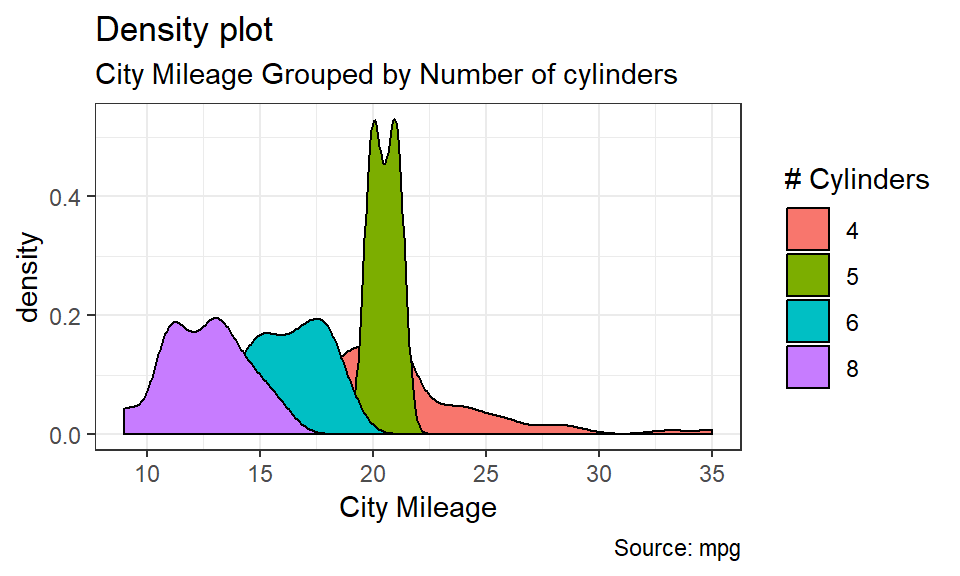

```r
ggplot(mpg, aes(cty)) +
  geom_density(aes(fill=factor(cyl))) +
    labs(title="Density plot",
         subtitle="City Mileage Grouped by Number of cylinders",
         caption="Source: mpg",
         x="City Mileage",
         fill="# Cylinders")
```

## Visualization: Heatmap

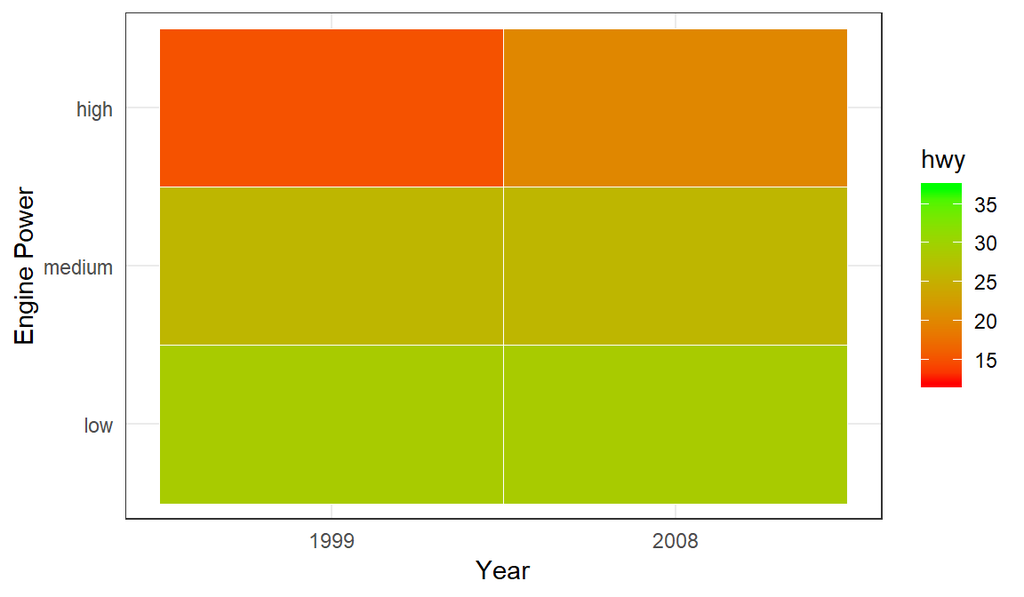

```r
ggplot(mpg, aes(x = as.factor(year), y = displ_grp)) +
  geom_tile(aes(fill = hwy), color = "white") +
  scale_fill_gradient(low = "red", high = "green") +
  theme(axis.ticks = element_blank()) +
  labs(x = "Year", y = "Engine Power")
```

## Visualization: Faceting

Combine multiple plots by adding two additional categorical attributes.

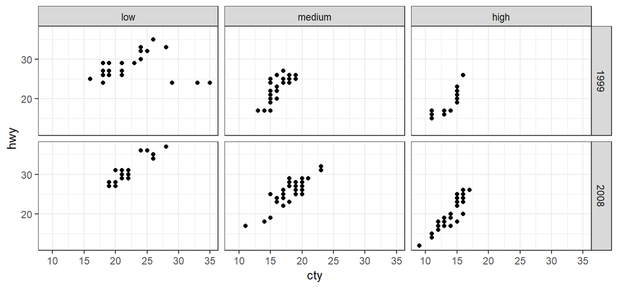

```r
ggplot(mpg, aes(cty, hwy)) +
  geom_point() +
  facet_grid(year ~ displ_grp)
```

## Setup Python in Rmarkdown

```r
library(reticulate)
use_python("C:/Users/ylin65/AppData/Local/Programs/Python/Python37/python.exe", required = T)
py_discover_config()
```

```
## python:         C:/Users/ylin65/AppData/Local/Programs/Python/Python37/python.exe
## libpython:      C:/Users/ylin65/AppData/Local/Programs/Python/Python37/python37.dll
## pythonhome:     C:\Users\ylin65\AppData\Local\Programs\Python\Python37
## version:        3.7.4 (tags/v3.7.4:e09359112e, Jul  8 2019, 20:34:20) [MSC v.1916 64 bit (AMD64)]
## Architecture:   64bit
## numpy:          C:\Users\ylin65\AppData\Local\Programs\Python\Python37\lib\site-packages\numpy
## numpy_version:  1.17.1
##
## NOTE: Python version was forced by use_python function
```

## Data exploration

```python
import pandas as pd
import numpy as np
mpg = pd.DataFrame(r.mpg)
mpg.info()
```

```
## <class 'pandas.core.frame.DataFrame'>
## RangeIndex: 234 entries, 0 to 233
## Data columns (total 12 columns):
## manufacturer    234 non-null category
## model           234 non-null category
## displ           234 non-null float64
## year            234 non-null int32
## cyl             234 non-null int32
## trans           234 non-null category
## drv             234 non-null category
## cty             234 non-null int32
## hwy             229 non-null float64
## fl              234 non-null category
## class           234 non-null category
## displ_grp       234 non-null category
## dtypes: category(7), float64(2), int32(3)
## memory usage: 11.6 KB
```

```python
mpg.describe()
```

```
##             displ         year         cyl         cty         hwy
## count  234.000000   234.000000  234.000000  234.000000  229.000000
## mean     3.471795  2003.500000    5.888889   16.858974   23.179039
## std      1.291959     4.509646    1.611534    4.255946    5.552643
## min      1.600000  1999.000000    4.000000    9.000000   12.000000
## 25%      2.400000  1999.000000    4.000000   14.000000   18.000000
## 50%      3.300000  2003.500000    6.000000   17.000000   24.000000
## 75%      4.600000  2008.000000    8.000000   19.000000   27.000000
## max      7.000000  2008.000000    8.000000   35.000000   37.000000
```

## Data Discretization

```python
mpg['displ_grp_py'] = pd.qcut(mpg.displ, 3,
                    labels = ["low", "medium", "high"])
mpg.groupby(['displ_grp_py']).agg({'displ': ['count', 'mean']})
```

```
##              displ
##              count      mean
## displ_grp_py
## low             82  2.137805
## medium          81  3.375309
## high            71  5.122535
```

## Data Normalization and Standardization

```python
from sklearn import preprocessing
mpg['displ_scale'] = preprocessing.scale(mpg['displ'])
mpg['displ_scale'].describe().round(2)
```

```
## count    234.00
## mean      -0.00
## std        1.00
## min       -1.45
## 25%       -0.83
## 50%       -0.13
## 75%        0.88
## max        2.74
## Name: displ_scale, dtype: float64
```

## One Hot Encoding and Label Encoding

```python
mpg_drv = pd.concat([mpg, pd.get_dummies(mpg["drv"], prefix="drv")], axis=1)
mpg_drv.sample(n=mpg_drv.shape[0]).head(10)
```

```
##     manufacturer               model  displ  ...  drv_4  drv_f drv_r
## 208   volkswagen                 gti    2.0  ...      0      1     0
## 176       toyota         4runner 4wd    3.4  ...      1      0     0
## 6           audi                  a4    3.1  ...      0      1     0
## 183       toyota               camry    3.0  ...      0      1     0
## 165       subaru         impreza awd    2.2  ...      1      0     0
## 81          ford        explorer 4wd    4.6  ...      1      0     0
## 120      hyundai             tiburon    2.7  ...      0      1     0
## 122         jeep  grand cherokee 4wd    3.0  ...      1      0     0
## 188       toyota        camry solara    2.4  ...      0      1     0
## 196       toyota             corolla    1.8  ...      0      1     0
##
## [10 rows x 17 columns]
```

## Data Outliers and Noises

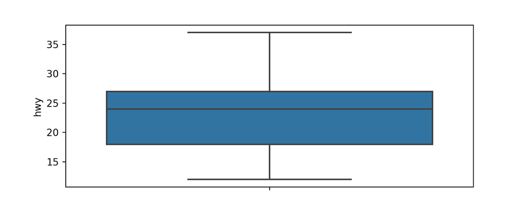

```python
import seaborn as sns
import matplotlib.pyplot as plt
sns.boxplot(y="hwy", data=mpg)
plt.show()
```

## Remove Duplicate Data Records

```python
mpg2 = mpg.drop_duplicates(keep="first")
diff = mpg.shape[0] - mpg2.shape[0]
print(f"There are {diff} duplicate records")
```

```
## There are 9 duplicate records
```

```python
mpg[mpg.duplicated()]
```

```
##     manufacturer                model  ...  displ_grp_py  displ_scale
## 20     chevrolet   c1500 suburban 2wd  ...          high     1.418098
## 40         dodge          caravan 2wd  ...        medium    -0.133257
## 42         dodge          caravan 2wd  ...        medium    -0.133257
## 53         dodge    dakota pickup 4wd  ...          high     0.952691
## 60         dodge          durango 4wd  ...          high     0.952691
## 67         dodge  ram 1500 pickup 4wd  ...          high     0.952691
## 68         dodge  ram 1500 pickup 4wd  ...          high     0.952691
## 79          ford         explorer 4wd  ...        medium     0.409717
## 103        honda                civic  ...           low    -1.451909
##
## [9 rows x 14 columns]
```

## Aggregation

```python
mpg2.groupby("manufacturer")['cty'].mean().sort_values(ascending=False)
```

```
## manufacturer
## honda         24.500000
## volkswagen    20.925926
## subaru        19.285714
## hyundai       18.642857
## toyota        18.529412
## nissan        18.076923
## audi          17.611111
## pontiac       17.000000
## chevrolet     15.055556
## ford          14.000000
## jeep          13.500000
## mercury       13.250000
## dodge         12.935484
## land rover    11.500000
## lincoln       11.333333
## Name: cty, dtype: float64
```

## Scatter Plot

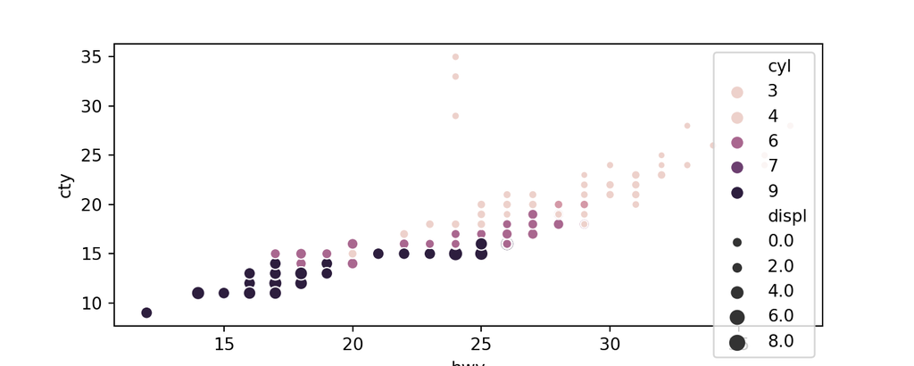

```python
sns.scatterplot(x="hwy", y="cty", hue="cyl", size="displ", data=mpg)
```